# Serum lipidomics in CIS versus MS: a site-confounded discovery analysis

Published

September 14, 2026

# 1 Summary

This report documents a discovery analysis of untargeted serum lipidomics data aimed at distinguishing Clinically Isolated Syndrome (CIS) from Multiple Sclerosis (MS). It covers the full pipeline: cohort construction, two independent feature-quality filters, correlation-based data reduction, penalised screening with false-discovery-rate control, and a bootstrap procedure that re-runs the *entire* pipeline in order to measure how much of the apparent result is optimism arising from having selected features on the same data.

The central finding is that one lipid feature (lip_727_65058_Da_672_95_s) is statistically robust in the pooled cohort, surviving a permutation test that corrects for 147 correlated tests while preserving the recruiting-centre structure. Its practical contribution, however, is small: adding the lipids to a model already containing centre, age and sex improves discrimination by less than four points on the C-index (Concordance Index). The reason is that the association is concentrated almost entirely at one centre — Eginitio, which contributes 20 of the 29 CIS patients. Within that centre alone the same feature is highly stable and strongly discriminating, but that analysis is exploratory, its effect size is inflated by selection, and no independent sample remains against which to validate it.

**NoteReproducibility**

All numbers in this document are read from three saved result objects. Two are produced by the analysis scripts (`ms_lipidomics_pipeline11.R` and `ms_lipidomics_pipeline9_EginitioOnly.R`); the third (`ms_lipidomics_results_supplementary.rds`) holds the permutation nulls, per-stratum fits, covariate-only baselines, the Site × lipid interaction test and the freeze-thaw degradation analysis, which span cohorts and so belong to neither pipeline. Nothing is transcribed and no model is refitted here: every table, figure and reported statistic is derived from those objects, including the candidate feature’s identity, which is read from the surviving feature name rather than hard-coded.

# 2 Study design and cohort construction

## Exclusions

The analysis cohort was constructed by removing three groups, each for a reason established before any lipid was examined.

Cohort construction

| Step | n | Reason |
| --- | --- | --- |
| Full dataset | 193 | — |
| Drop AUTH batch1 | 143 | Freeze-thaw degradation; retained as a technically compromised replication set |
| Drop healthy controls | 128 | Off-question for CIS-vs-MS; n=15, 73% from one centre |
| Drop Larissa | 113 | MS patients only — zero within-site information, causes complete separation |

## Group composition by centre

Site × Group composition (analysis cohort, n = 113)

Eginitio supplies 20 of 29 CIS patients (69%)

| Site | CIS | MS | CIS share of that site |
| --- | --- | --- | --- |
| Eginitio | 20 | 23 | 47% |
| Attikon | 4 | 30 | 12% |
| AUTH_batch2 | 5 | 31 | 14% |

This table indicates the Site confounding issue. The CIS-versus-MS contrast is, to a first approximation, an Eginitio-versus-elsewhere contrast. Nearly 70% of all CIS patients in the study (20 out of 29) came from a single hospital—Eginitio. Meanwhile, the other two hospitals supplied overwhelmingly MS patients. Because the patient types are divided this way, comparing CIS vs. MS is practically the same as comparing Eginitio Hospital vs. Other Hospitals. If Eginitio handled its blood samples slightly differently (such as using a different tube, a different freezer temperature, or a different processing time), that routine hospital quirk would show up almost exclusively in the CIS group. A harmless lab difference could easily trick someone into thinking it was a biological marker of the disease. To prevent hospital habits from masquerading as biological discoveries, the analysis was therefore centre-adjusted.

## Effective sample size and the degrees-of-freedom budget

With a binary outcome, the information available is governed by the smaller class. Harrell’s effective sample size is $n - (n_1^3 + n_0^3)/n^2$:

Effective sample size

The minority class is the binding constraint

| Analysis | n | CIS | MS | Effective n | df budget (n/20 – n/10) |
| --- | --- | --- | --- | --- | --- |
| Primary | 113 | 29 | 84 | 64.7 | 3.2 – 6.5 |
| Eginitio | 43 | 20 | 23 | 32.1 | 1.6 – 3.2 |

This budget is the reason every downstream choice is conservative: one lipid screened at a time, penalised final models, and no interaction terms.

# 3 Feature processing

## Two independent quality filters

Of 1,353 detected lipid features, 232 survived two filters that test different things and must both be applied.

Retention-time / mass filter (method-based, data-independent). Feature names encode accurate mass and retention time. A substantial fraction of features fell in the void volume (RT < 30 s, the solvent front) or the post-gradient wash (RT > 950 s) i.e. unretained contaminants and background ions rather than lipids.

Within-site detection filter (≥ 90% at *every* centre). Detection consistency alone is not sufficient evidence that a feature is an analyte: background ions are often detected in *every* sample precisely because they are systematic contamination. In this dataset 294 features passed detection filtering while sitting in the junk retention-time zone, so applying only one filter would have retained them.

## Attikon detection fingerprint

Importance of stratifying the detection filter by centre:

An investigation of features whose detection was mutually exclusive across samples (74 pairs, against a permutation null with a maximum of 2) found that clustering samples on those features produced a clean group of 29 samples, all from Attikon. This looks like a pre-analytical difference — collection tube, clotting time, storage, or extraction — not biology, and it does not seem to be analytical drift: injection order was randomised across centres, and within-Eginitio run order does not predict group (p = 0.40).

In other words, Attikon had an unusual pattern. We noticed 74 pairs of chemical signals that were mutually exclusive i.e. if Signal A was present, Signal B was never there. By random chance, one would expect at most 2 such pairs. Then, grouping samples based on these signals revealed that 29 samples stood completely apart from all others and that every single one of those came from Attikon hospital. This wasn’t because Attikon’s patients were biologically unique. It was a “pre-analytical” difference—meaning it stemmed from how the samples were handled before reaching the lab (such as using a different brand of blood collection tube, a different clotting time, or different freezer storage). Also, because samples from different centers were analyzed in a randomized order, instrument drift or testing day variations could not explain the pattern.

Because the affected features would have appeared, in an unadjusted screen, as MS-enriched (Attikon being 4 CIS / 30 MS), a within-site detection threshold was adopted, and the idea of using detection status itself as a binary predictor was abandoned.

## Data reduction by correlation clustering

Due to heavy collinearity, features were grouped by observed-only Spearman correlation and each cluster represented by its most central member.

**ImportantClustering used observed values only**

An early diagnostic showed that imputing below-detection values *before* clustering inflated the similarity of feature pairs that shared missing samples: co-missingness raised post-imputation similarity by roughly 0.0065 ρ per shared missing sample (t = 22.7), with the effect reaching ~0.06 ρ for the most co-missing pairs. Since missingness was itself site-structured, this would have produced clusters encoding centre rather than biology. Clustering was therefore performed on pairwise-complete rank correlations of observed values only, and imputation confined to the modelling step.

Data-reduction settings

Complete linkage at h = 0.50 guarantees |ρ| ≥ 0.71 for every within-cluster pair

| Parameter | Primary | Eginitio |
| --- | --- | --- |
| Detection threshold | 0.90 per site | 0.90 |
| Features retained | 232 | 322 |
| Similarity | Spearman ρ² | Spearman ρ² |
| Linkage | complete | complete |
| Cut height (1 − ρ²) | 0.50 | 0.50 |
| Representatives | 147 | 240 |
| Named lipids among representatives | 47 | 78 |

The cut height parameter was selected on outcome-blind criteria only such as cluster count, proportion of features in genuine (non-singleton) clusters, and largest cluster size, at the point beyond which maximum cluster size grows abruptly i.e. we gradually relaxed the parameter to group as many features as possible, but stopped just before having a “mega-cluster” that can contain unrelated features.

**NoteHierarchical Clustering Linkage**

The complete linkage method can be briefly described as follows: two groups are only merged if the two least similar items between them are still similar enough. This ensures every feature inside a cluster is tightly related to every other feature in that cluster.

# 4 Statistical approach

## Screening

Each cluster representative was tested for association with Group, adjusting for centre, age and sex:

$$\text{logit}\,P(\text{MS}) = \beta_0 + \beta_1\text{Site} + f(\text{Age}) + \beta_3\text{Gender} + \beta_4\,\text{lipid}_j$$

with the lipid entering linearly on the $\log_2$ scale (so a coefficient is an odds ratio *per doubling* of abundance), and Benjamini–Hochberg control across representatives.

Fitting used Firth’s penalised likelihood rather than ordinary maximum likelihood. With 29 CIS patients, unpenalised fits can separate i.e. the estimate diverges, the deviance goes to zero, and the feature would go through FDR as a false discovery. Firth guarantees finite estimates, and unlike ridge penalties its penalised profile likelihood ratio test retains a valid $\chi^2$ reference distribution, so its $p$-values remain legitimate inputs to FDR.

**NoteVerification of test calibration**

Permuting Group within centre and re-running the screen 400 times gave a rejection rate of 0.0503 at $\alpha = 0.05$ i.e. essentially exact. Permuting freely (breaking the Group–Site association as well) gave 0.0402, i.e. mildly conservative, confirming that the within-site permutation is the correct null.

## Penalisation of the final model

The combined model containing surviving lipids was penalised by bisecting a single ridge parameter to a target effective degrees of freedom, fitting penalised from the first call. This mattered because an earlier version selected the penalty from an unpenalised starting fit, which failed in 18% of bootstrap replicates when the number of survivors approached the sample size.

Targets were derived from an AICc trace on each full-data model and, in the Eginitio analysis, checked against calibration.

## Bootstrapping Procedure

Reported performance is corrected for optimism using 400 bootstrap replicates in which the entire pipeline is re-run: detection filtering, similarity computation, clustering, representative selection, imputation, screening, FDR, and model fitting. Only the fixed, outcome-blind constants (retention-time window, detection threshold, cut height, model formula) are held constant.

This distinction is quantitatively large. Validating only the *fixed* final model with `rms::validate` gives a Dxy optimism of 0.082; wrapping the whole pipeline gives 0.145. The difference of 0.063 in Dxy is the cost of having screened 147 representatives, and it would have been invisible to any procedure that treats the selected features as pre-specified.

# 5 Primary analysis (n = 113, three centres)

## Screening result

Primary screen: top 15 representatives by p-value

Firth penalised likelihood, adjusted for Site + rcs(Age,3) + Gender

| Representative | OR per doubling | p | q | Implausible |
| --- | --- | --- | --- | --- |
| lip_727_65058_Da_672_95_s | 0.2393 | 4.25e-05 | 0.00625 | FALSE |
| lip_662_44636_Da_484_50_s | 0.0132 | 3.88e-03 | 0.28500 | TRUE |
| lip_600_51165_Da_722_22_s | 0.3358 | 6.22e-03 | 0.30500 | FALSE |
| lip_456_29975_Da_287_20_s | 2.1332 | 1.62e-02 | 0.54100 | FALSE |
| LPC_18_3 | 0.4947 | 2.29e-02 | 0.54100 | FALSE |
| LPC_20_3 | 0.3792 | 2.33e-02 | 0.54100 | FALSE |
| PC_20_3_16_0 | 0.3447 | 2.57e-02 | 0.54100 | FALSE |
| lip_646_45101_Da_559_81_s | 0.0327 | 4.16e-02 | 0.76500 | TRUE |
| PC_34_4_1 | 0.5198 | 5.43e-02 | 0.79900 | FALSE |
| CE_16_0_1 | 1.2272 | 5.65e-02 | 0.79900 | FALSE |
| PC_16_0_16_1 | 0.5639 | 5.99e-02 | 0.79900 | FALSE |
| PC_36_6 | 0.5914 | 7.21e-02 | 0.79900 | FALSE |
| LPC_14_0 | 0.5588 | 7.66e-02 | 0.79900 | FALSE |
| lip_754_53417_Da_299_00_s | 0.6509 | 7.87e-02 | 0.79900 | FALSE |
| lip_649_63663_Da_596_89_s | 0.2942 | 8.63e-02 | 0.79900 | FALSE |

Features surviving BH-FDR at q < 0.05

| Feature | OR per doubling | p | q |
| --- | --- | --- | --- |
| lip_727_65058_Da_672_95_s | 0.239 | 4.25e-05 | 0.00625 |

## Permutation-based significance

Westfall–Young min-P family-wise significance

400 permutations; the correlation structure among features is preserved

| Analysis | Permutations | Null rejection rate at α=0.05 | Observed minimum p | Permutation min-P p-value | Note |
| --- | --- | --- | --- | --- | --- |
| Primary (within-site permutation) | 400 | 0.0503 | 4.25e-05 | 0.0075 | stratified null |
| Primary (free permutation) | 400 | 0.0402 | 4.25e-05 | 0.0050 | conservative |
| Eginitio | 400 | 0.0379 | 5.51e-08 | 0.0025 | floor of 1/401 |

The stratified permutation is the most accurate approach: it preserves the centre structure that the entire analysis is designed to control for, and it is the better-calibrated null.

## Selection stability

Bootstrap inclusion frequency (primary analysis)

Proportion of 400 replicates in which each feature survived FDR

| Feature | Times selected | Inclusion frequency |
| --- | --- | --- |
| lip_727_65058_Da_672_95_s | 200 | 0.517 |
| lip_662_44636_Da_484_50_s | 143 | 0.370 |
| lip_682_59229_Da_673_09_s | 91 | 0.235 |
| lip_456_29975_Da_287_20_s | 70 | 0.181 |
| lip_698_58797_Da_598_54_s | 68 | 0.176 |
| lip_600_51165_Da_722_22_s | 66 | 0.171 |
| lip_646_45101_Da_559_81_s | 50 | 0.129 |
| PC_20_3_16_0 | 45 | 0.116 |
| LPC_14_0 | 36 | 0.093 |
| PC_18_2_14_0 | 32 | 0.083 |
| lip_754_53417_Da_299_00_s | 32 | 0.083 |
| LPC_18_3 | 31 | 0.080 |
| LPC_20_3 | 30 | 0.078 |
| lip_649_63663_Da_596_89_s | 30 | 0.078 |
| CE_16_0_1 | 29 | 0.075 |

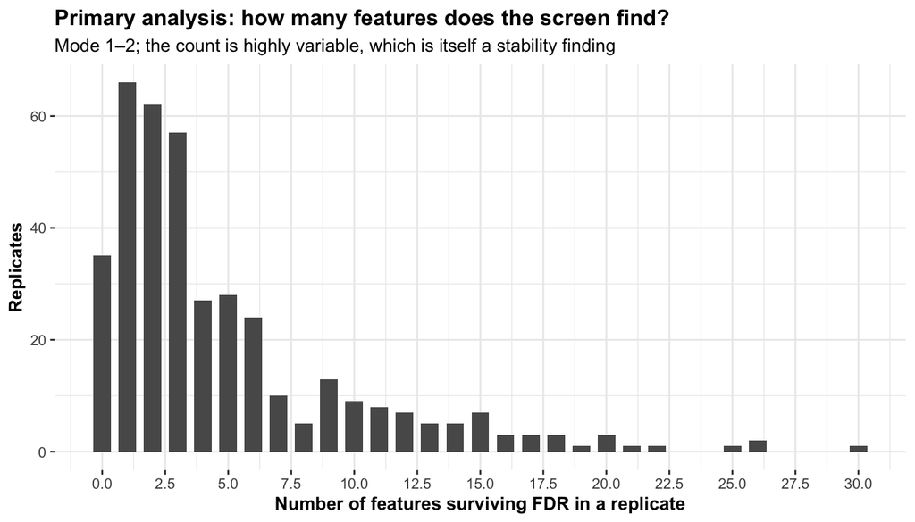

Two features of this distribution matter. The candidate is re-selected in about half of the replicates, and roughly nine in ten replicates find at least one feature; but the *number* found ranges widely, so the hit count is not a stable property of the data.

The third-ranked feature is the candidate’s own co-eluting cluster-mate. The *cluster* is selected in approximately 75% of replicates while which member represents it varies, which is a redundancy artefact rather than two independent findings.

## Optimism-corrected performance

Bootstrap-corrected performance

rms::validate layout; the whole pipeline is re-run in each replicate

| Model | Metric | Apparent | Optimism | Corrected | n |
| --- | --- | --- | --- | --- | --- |
| Inference (Site in) | Brier | 0.102 | -0.028 | 0.129 | 387 |
| Prediction (Site out) | Brier | 0.104 | -0.029 | 0.133 | 387 |
| Inference (Site in) | C | 0.832 | 0.073 | 0.760 | 387 |
| Prediction (Site out) | C | 0.830 | 0.074 | 0.757 | 387 |
| Inference (Site in) | Dxy | 0.664 | 0.145 | 0.519 | 387 |
| Prediction (Site out) | Dxy | 0.660 | 0.147 | 0.513 | 387 |
| Inference (Site in) | Intercept | 0.000 | 0.190 | -0.190 | 387 |
| Prediction (Site out) | Intercept | 0.000 | 0.067 | -0.067 | 387 |
| Inference (Site in) | R2 | 0.518 | 0.152 | 0.366 | 387 |
| Prediction (Site out) | R2 | 0.512 | 0.158 | 0.355 | 387 |
| Inference (Site in) | Slope | 1.000 | -0.151 | 1.151 | 387 |
| Prediction (Site out) | Slope | 1.000 | -0.007 | 1.007 | 387 |

## Incrementing over the covariate skeleton

Corrected C-index: covariates alone versus covariates plus lipids

Both figures optimism-corrected, so the comparison is like-for-like

| Analysis | Covariate model | C (covariates only) | C (with lipids) | Increment |
| --- | --- | --- | --- | --- |
| Primary | Site + rcs(Age,3) + Gender | 0.721 | 0.760 | 0.038 |
| Eginitio | Age + Gender | 0.573 | 0.883 | 0.309 |

In the primary analysis the lipids add less than four points of C-index over centre, age and sex. Centre is doing nearly all of the discriminating. In the Eginitio analysis, where there is no centre term, the covariate model is barely better than chance and the lipid does almost all of the work.

**CautionComparison asymmetry**

The covariate-only model is bootstrapped without a selection step, while the full model’s correction absorbs the feature selection screening. The increment is therefore *conservative* and the lipid model is held to the stricter standard i.e. the increment improvements could be an under-statement.

## Calibration

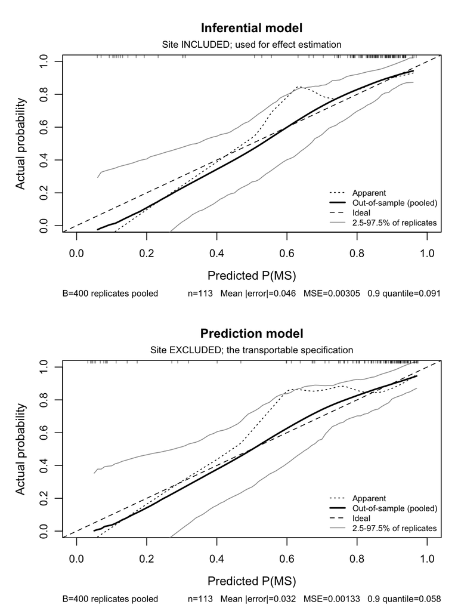

Two models are fitted in every bootstrap replicate and both are shown above. They answer different questions and are not interchangeable:

- The *inferential* model keeps Site. Its job is to give lipid coefficients that are not contaminated by centre effects, and it is the model behind every effect estimate reported here. It cannot be deployed, because a fitted Site factor with three levels has no column for a patient from a fourth hospital.
- The *prediction* model drops Site. Its job is to be usable somewhere else. Its coefficients should not be read as effect sizes, since with Site removed they absorb some of the between-centre variation.

The features entering the two are identical — the screening step is the same, and Site is only dropped afterwards — so any difference between the panels is attributable to the Site term and the shrinkage alone.

The reported curve in each panel is the pooled out-of-sample curve: each replicate’s model scored on the original data. This is already a held-out quantity and requires no optimism correction.

**NoteNot using the classic bias-corrected curve**

The standard estimator, `apparent − mean(train − test)`, assumes in-sample calibration is optimistic and produces the classic bias-corrected curve. That assumption fails for a penalised *selection* pipeline. Replicate models carry between one and thirty survivors, so reaching a fixed effective-df target requires very different amounts of shrinkage; their median apparent calibration slope was 1.48, against 1.05 for the full-data model which has a single survivor. Heavily shrunk models are *under*-dispersed in-sample, so `train − test` came out negative and the “correction” pushed the curve away from the diagonal. This seems to be a general property of bootstrapping penalised selection.

# 6 Site-heterogeneity

## Leave-one-site-out and per-stratum estimates

Per-stratum Firth estimates for the candidate feature

Unadjusted within-stratum fits

| Stratum | CIS | MS | log OR | OR | 95% CI |
| --- | --- | --- | --- | --- | --- |
| Eginitio | 20 | 23 | -3.073 | 0.046 | 0.005 – 0.185 |
| Attikon | 4 | 30 | 0.054 | 1.056 | 0.248 – 1.688 |
| AUTH_batch2 | 5 | 31 | 0.138 | 1.147 | 0.541 – 1.823 |
| AUTH_batch1 | 13 | 34 | -0.572 | 0.564 | 0.084 – 3.620 |

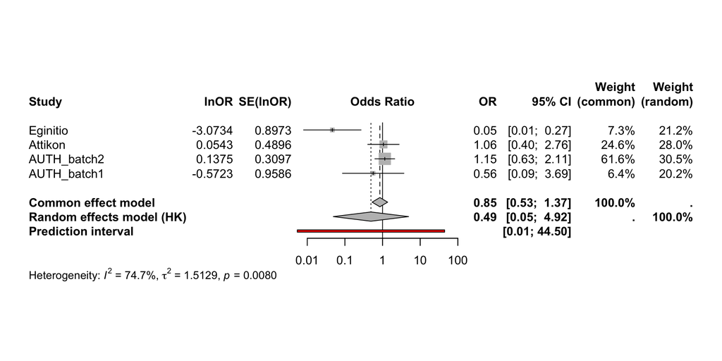

Heterogeneity is substantial and statistically significant: $I^2 = 74.7\%$, $\tau^2 = 1.51$, Cochran’s $Q = 11.84$ on 3 df, $p = 0.008$. A formal Site × lipid interaction test in the pooled model agreed i.e. $\chi^2 = 14.92$, 2 df, $p = 5.8\times 10^{-4}$.

The prediction interval (red horizontal bar) denotes the plausible odds ratio at an unsampled centre. It spans 0.005 to 44.5. This indicates that the selected feature can not be reliably used at a fourth new hospital.

**WarningForest plot interpretation**

Three of the four strata (Eginitio, Attikon, AUTH batch2) *are* the samples from which this feature was selected, so decomposing that result by centre generates no new evidence. Only AUTH batch1 is independent of the selection step, and it was inconclusive: OR 0.56 (0.09 – 3.69), with roughly 38% power against the pooled effect (the effect pointed the same way but the confidence interval was wide enough to include no effect at all).

## Sparse centres

# 7 Eginitio-only analysis (exploratory)

**ImportantExploratory analysis**

The Eginitio stratum was selected after observing the site-stratified results. The inclusion criterion, that strata contributing fewer than ten CIS patients cannot support a centre-specific coefficient, depends only on the Site × Group composition, which was fixed at recruitment and known before any lipid was examined. Nevertheless, the rule was formulated post hoc, and no $p$-value or confidence interval reported in this section has its nominal coverage (i.e. should be read as if it had been planned from the start).

## Selection stability

Bootstrap inclusion frequency (Eginitio only)

The candidate is re-selected in 94% of replicates

| Feature | Times selected | Inclusion frequency |
| --- | --- | --- |
| lip_727_65058_Da_672_95_s | 375 | 0.938 |
| lip_662_44636_Da_484_50_s | 110 | 0.275 |
| lip_853_56140_Da_280_34_s | 100 | 0.250 |
| lip_492_49022_Da_619_23_s | 98 | 0.245 |
| lip_698_58797_Da_598_54_s | 89 | 0.222 |
| lip_512_36280_Da_444_59_s | 81 | 0.202 |
| lip_754_53417_Da_299_00_s | 78 | 0.195 |
| CE_18_3_2 | 73 | 0.182 |
| lip_646_45101_Da_559_81_s | 70 | 0.175 |
| CE_20_4_1 | 68 | 0.170 |
| lip_682_59229_Da_673_09_s | 57 | 0.142 |
| lip_753_68401_Da_668_95_s | 48 | 0.120 |
| SM_30_1 | 46 | 0.115 |
| PC_20_3_16_0 | 44 | 0.110 |
| lip_743_64427_Da_598_46_s | 44 | 0.110 |

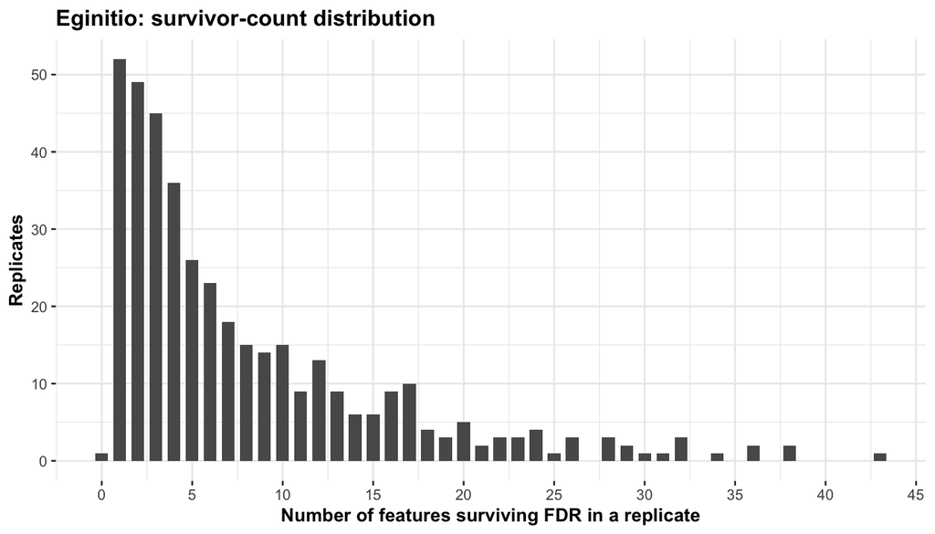

The contrast with the primary analysis is striking. Despite half the effective sample size, the feature is far more stably selected within Eginitio (0.94) than in the pooled cohort (0.52). Adding the 70 non-Eginitio samples makes the signal harder to find, because those samples do not carry it.

## Performance and calibration

Eginitio: bootstrap-corrected performance

| Model | Metric | Apparent | Optimism | Corrected |
| --- | --- | --- | --- | --- |
| Inference (df 2.5) | Brier | 0.081 | -0.052 | 0.133 |
| Prediction (df 4) | Brier | 0.073 | -0.065 | 0.138 |
| Inference (df 2.5) | C | 0.959 | 0.076 | 0.883 |
| Prediction (df 4) | C | 0.965 | 0.072 | 0.893 |
| Inference (df 2.5) | Dxy | 0.917 | 0.152 | 0.765 |
| Prediction (df 4) | Dxy | 0.930 | 0.143 | 0.787 |
| Inference (df 2.5) | Intercept | 0.000 | 0.083 | -0.083 |
| Prediction (df 4) | Intercept | 0.000 | 0.011 | -0.011 |
| Inference (df 2.5) | R2 | 0.743 | 0.186 | 0.557 |
| Prediction (df 4) | R2 | 0.795 | 0.236 | 0.559 |
| Inference (df 2.5) | Slope | 1.000 | -0.720 | 1.720 |
| Prediction (df 4) | Slope | 1.000 | -0.035 | 1.035 |

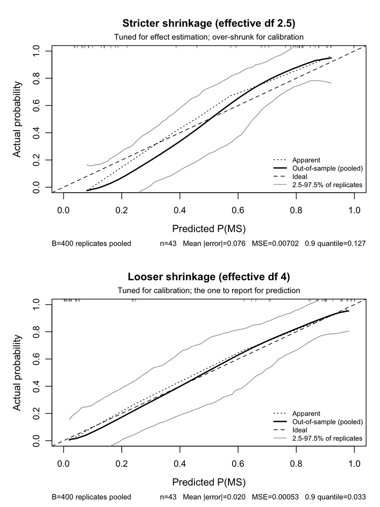

There is no Site term at a single centre, so unlike the primary analysis these two panels do not contrast Site-in against Site-out. They contrast two amounts of shrinkage applied to the same model, fitted to the same lipid.

The two therefore rank patients almost identically — corrected discrimination differs by less than two hundredths — and disagree only about how confidently that ranking should be translated into probabilities. The upper panel is shrunk harder, which yields more conservative coefficients at the cost of predictions that are systematically too cautious: its calibration slope is 1.72, meaning the observed frequencies rise faster than the predicted ones. The lower panel is shrunk less and its slope is 1.04, so its predicted probabilities can be read at face value.

The upper is the model behind any effect estimate, the lower is the model behind any predicted probability.

## The covariate baseline

```
Logistic Regression Model

lrm(formula = Group ~ rcs(Age, 3) + Gender, data = d_cov, x = TRUE,
    y = TRUE)

                      Model Likelihood     Discrimination    Rank Discrim.
                            Ratio Test            Indexes          Indexes
Obs            43    LR chi2      3.47     R2       0.104    C       0.658
 CIS           20    d.f.            3     R2(3,43) 0.011    Dxy     0.315
 MS            23    Pr(> chi2) 0.3240    R2(3,32.1)0.015    gamma   0.317
max |deriv| 1e-11                          Brier    0.229    tau-a   0.161

            Coef    S.E.   Wald Z Pr(>|Z|)
Intercept    0.1299 2.0567  0.06  0.9496
Age          0.0168 0.0667  0.25  0.8010
Age'        -0.0486 0.0862 -0.56  0.5726
Gender=Male -0.9034 0.7080 -1.28  0.2020
```

Age and sex are individually non-significant and jointly explain almost nothing at this centre, which is why the lipid increment is so large: the model has essentially no competition.

## Effect size

The reported effect comes from the Firth linear fit, which is the model the screen actually used, has no evidence of nonlinearity (shape test $p = 0.80$), and yields a profile-likelihood interval:

Candidate feature effect size, Eginitio only

Higher abundance is associated with CIS rather than MS

| Quantity | Value |
| --- | --- |
| OR per doubling of abundance | 0.042 (95% CI 0.0039 – 0.186) |
| OR over the observed interquartile range (1.54 doublings) | 0.0076 |
| Unpenalised (ML) estimate for comparison | 0.018 |
| Firth shrinkage of the log-odds | 21% |
| Median log2 abundance, CIS | 14.7 (IQR 14.4 – 14.8) |
| Median log2 abundance, MS | 13.2 (IQR 12.8 – 13.5) |

The magnitude is unusually large for a serum lipid, and the reason is visible in the raw distributions: the interquartile ranges of the two groups do not overlap at this centre. The odds ratio is large because the groups barely overlap on this measurement, not because a small shift produces a huge effect.

**CautionTwo distinct biases**

Firth corrects bias arising from sparse data; the estimate moved from 0.018 to 0.042, a 21% reduction in the log-odds. It does nothing about bias arising from selection. The reported figure is therefore a sparsity-corrected estimate of a coefficient that remains selection-inflated, and its confidence interval conditions on the feature having been chosen as the best of 240 candidates.

## Sub-threshold features

Twenty features reached nominal $p \le 0.05$ in the Eginitio screen against a permutation-null median of 8 — an excess of roughly 2–4× that is consistent across every tail threshold tested, but which does not reach significance ($p \approx 0.06$, Monte Carlo SE ≈ 0.012 at 400 permutations). Their per-feature permutation $p$-values match their asymptotic values closely, so the enrichment is not a calibration artefact; the features are simply weak.

Features below nominal p = 0.05 that did not survive FDR

Listed for hypothesis generation, not as findings

| Feature | OR per doubling | p | q |
| --- | --- | --- | --- |
| lip_492_49022_Da_619_23_s | 0.06190 | 0.00630 | 0.56 |
| lip_754_53417_Da_299_00_s | 0.39800 | 0.00826 | 0.56 |
| lip_662_44636_Da_484_50_s | 0.00531 | 0.00996 | 0.56 |
| CE_20_4_1 | 8.61000 | 0.01440 | 0.56 |
| lip_512_36280_Da_444_59_s | 54.30000 | 0.01770 | 0.56 |
| CE_18_3_2 | 0.34900 | 0.01780 | 0.56 |
| lip_635_62177_Da_581_46_s | 0.51900 | 0.01960 | 0.56 |
| SM_30_1 | 0.39400 | 0.02330 | 0.56 |
| lip_646_45101_Da_559_81_s | 0.00622 | 0.02340 | 0.56 |
| PC_20_3_16_0 | 0.25900 | 0.02970 | 0.56 |
| PC_40_5_1 | 0.20800 | 0.02990 | 0.56 |
| PC_33_1 | 0.32100 | 0.03450 | 0.56 |
| lip_773_55691_Da_297_20_s | 0.35500 | 0.03570 | 0.56 |
| PC_O_40_6_2 | 0.65300 | 0.03690 | 0.56 |
| lip_576_51083_Da_720_74_s | 0.51900 | 0.04190 | 0.56 |
| lip_600_51165_Da_722_22_s | 0.41400 | 0.04240 | 0.56 |
| lip_382_19724_Da_61_67_s | 0.19300 | 0.04370 | 0.56 |
| lip_753_68401_Da_668_95_s | 0.15600 | 0.04460 | 0.56 |
| lip_692_62946_Da_736_23_s | 0.28800 | 0.04660 | 0.56 |

The one worth naming individually is `lip_662_44636_Da_484_50_s`: inclusion frequency 0.37 in the primary analysis and 0.28 at Eginitio, adjusted $p = 0.0039$ with OR 0.013. It survives FDR in neither analysis, but it is the only secondary candidate that ranks near the top in both.

# 8 QAlb Sensitivity Analysis

## Adjustment for blood-brain-barrier integrity

The albumin quotient, QAlb, is CSF albumin divided by serum albumin and multiplied by 1000. Since albumin is made in the liver (instead of in the brain), whatever is found in cerebrospinal fluid has crossed the blood-brain barrier; the ratio can be therefore seen as a standard measure of how permeable that barrier is. A raised QAlb points to a leakier barrier.

This matters because of an alternative explanation for the candidate feature. If barrier permeability differs between CIS and MS patients, and if a leakier barrier changes what appears in serum, then a lipid associated with disease status might be tracking barrier integrity rather than anything specific to the disease. Adjusting for QAlb tests that: if the association were a barrier readout, it should shrink towards no effect once QAlb is in the model.

In addition, QAlb is not in the main model for a separate reason. Obtaining it requires a lumbar puncture, and a blood test that needs a lumbar puncture to work has given up its main practical advantage. It is used here only as a check on the candidate, not as a predictor.

### QAlb across the two groups

Albumin quotient by group

Analysis cohort, n = 113; no missing values

| Group | n | q25 | median | q75 |
| --- | --- | --- | --- | --- |
| MS | 84 | 3.13 | 3.96 | 6.10 |
| CIS | 29 | 3.91 | 4.78 | 6.78 |

The two groups overlap a great deal. The medians differ by about -0.82 units, while the middle half of each group spans roughly three times that, so a randomly picked CIS patient is only modestly more likely to have a higher QAlb than a randomly picked MS patient.

A rank test gives p = 0.056, which sits just outside the conventional 5% mark. That is not in tension with the overlap. A p-value combines the size of the shift with the sample size, so with 113 patients even a modest shift can approach the conventional threshold. What matters for this check is the size, and expressed relative to the spread within each group it is about a quarter of an interquartile range i.e. small.

Direction-wise the CIS patients sit slightly higher, instead of lower, the reverse of what we would expect if barrier damage simply accumulated over the course of the disease. This could be the case for one of the following two reasons:

- The initial inflammation during a first attack (CIS) causes just as much leakage as long-term disease (MS).
- Patients receiving treatment for long-term disease (MS) have less leakage than untreated first-attack patients (CIS).

Either way, because the barrier leakage is almost the same in both groups, it cannot explain the differences between them.

Every patient in the analysis cohort has a QAlb value, because lumbar puncture is part of standard diagnostic testing for both CIS and MS. This check therefore runs on measured values across the whole sample, with no imputation. It is also one place where excluding the healthy controls helps: they would mostly have had no CSF sample, since there is no clinical reason to perform a lumbar puncture on a healthy volunteer, and missingness would have lined up almost exactly with group membership i.e. restricting to CIS and MS removes the problem, because both groups get the procedure as a matter of clinical routine.

### The selected lipid feature, with and without adjustment

Candidate feature before and after adjustment for QAlb

Firth penalised fits; a ratio above 1 means the effect grew

| Analysis | OR per doubling | OR adjusted for QAlb | Ratio of log-odds |
| --- | --- | --- | --- |
| Primary (n = 113) | 0.2470 | 0.2530 | 0.983 |
| Eginitio (n = 43) | 0.0424 | 0.0306 | 1.103 |

Looking at the odds-ratios (i.e. OR), the association does not weaken. In the pooled or primary analysis the odds ratio is essentially unchanged; in the Eginitio only analysis it moves slightly further from 1, so the log-odds grows by about a tenth rather than shrinking. This indicates that whatever the top lipid is tracking, it is not blood-brain-barrier permeability. Nor is the reverse plausible (i.e. that barrier leakage is a step between disease and lipid, and adjusting for it has removed part of a real effect) since QAlb barely differs between the groups in the first place.

**NoteOR differences from an unpenalised fit**

The same comparison fitted without Firth’s penalty gives, at Eginitio, an odds ratio of 0.018 before adjustment and 0.008 after i.e. a shift of about 20% on the log-odds scale rather than the 10% reported above. Both of those come from an ordinary logistic model with five or six parameters fitted to 43 patients, only 20 of whom have CIS, which is exactly the situation where unpenalised estimates get pushed away from 1. Firth’s penalty pulls them back to 0.042 and 0.031, and roughly halves the apparent shift. The penalised figures are the ones used above, as they are throughout this report.

# 9 Technical quality control

## Freeze-thaw degradation in AUTH batch1

AUTH batch1 was excluded from discovery and its degradation characterised directly. Both AUTH batches were analysed in the same instrument sequence, so everything downstream of the freezer was identical, making the comparison a clean natural experiment. The comparison was restricted to MS patients so that group composition cannot explain it.

Product-to-substrate ratios, AUTH batch1 vs batch2

MS patients only

| metric | batch1 | batch2 | p_value | direction |
| --- | --- | --- | --- | --- |
| LPC / PC (median ratio) | 0.3395937 | 0.2140305 | 2.804034e-12 | product enriched in batch1 |
| DG / TG (median ratio) | 1.6828282 | 1.3539890 | 1.710382e-01 | product enriched in batch1 |

Every substrate class is depleted in batch1 (PE, PC, PI, CE, SM) and every hydrolysis product enriched (LPC, DG, Cer) i.e. phosphatidylcholine loses a chain to become lysophosphatidylcholine, triacylglycerol becomes diacylglycerol, sphingomyelin becomes ceramide (Ishikawa et al. 2014; Reis et al. 2021).

That pattern is suggestive but not decisive on its own, because the two batches are different patients. Phospholipase A2 is active in vivo as well as in a freezer, so a group of patients with more inflammation would also show a raised product-to-substrate ratio. A test that a population difference *cannot* imitate is needed, and the enzyme’s positional chemistry supplies one.

Phosphatidylcholine has a glycerol backbone carrying a fatty acid at position *sn*-1, a second at *sn*-2, and a phosphocholine head group at *sn*-3. Phospholipase A2 cleaves specifically at *sn*-2, releasing that chain and leaving lysophosphatidylcholine behind (Khan and Ilies 2023; Mouchlis and Dennis 2019). Biology places these chains non-randomly: *sn*-1 typically carries a saturated fatty acid (16:0, 18:0) while *sn*-2 typically carries an unsaturated or polyunsaturated one (18:2, 20:4, 22:6) (Mouchlis and Dennis 2019). That asymmetry is maintained by the Lands cycle, in which phospholipids are deacylated and reacylated with different chains, preferentially incorporating polyunsaturated fatty acids (Jackson, Abate, and Tonks 2008). Double bonds are therefore concentrated at exactly the position the enzyme attacks.

Feature names give sum composition, `PC_38_6` is 38 carbons and 6 double bonds across both chains, so a species with many double bonds must be carrying a polyunsaturated chain, almost certainly at *sn*-2. If phospholipase activity caused the depletion, the loss should therefore scale with double-bond count. A difference between two patient populations offers no reason for such a gradient to exist.

Double-bond specificity of the batch1 depletion

Rank correlation is of most importance: two outliers at db = 3 inflate the OLS residual variance

| Class | Species tested | OLS slope | OLS p | Spearman rho | Spearman p |
| --- | --- | --- | --- | --- | --- |
| PC (substrate) | 21 | -0.118 | 0.0888 | -0.563 | 0.00781 |
| LPC (product) | 10 | 0.004 | 0.8150 | 0.151 | 0.67700 |

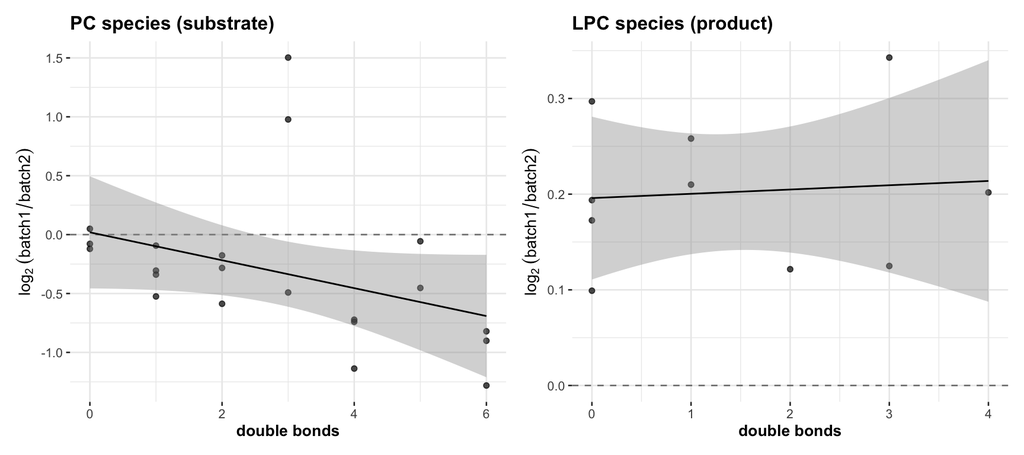

Polyunsaturated PC species are depleted *more* than saturated ones (Spearman $\rho = -0.56$, $p = 0.0078$), which is the *sn*-2 positional specificity a phospholipase produces (Khan and Ilies 2023; Mouchlis and Dennis 2019) and which a difference between two patient populations would not generate.

The gradient is present on the substrate side. The product side is less tidy: LPC species are uniformly enriched (intercept +0.20, p = 0.0007) but show no double-bond trend. If cleavage were purely at *sn*-2 the retained *sn*-1 chain would usually be saturated, so enrichment should have concentrated among low-double-bond LPC species. Flat enrichment instead suggests either mixed phospholipase A1 and A2 activity, or that LPC is itself being consumed further by lysophospholipases, which would flatten the product profile.

**NoteTwo caveats on the double-bond argument**

Sum composition does not say *which* chain carries the double bonds (Liebisch et al. 2013, 2020), so double-bond count is a proxy for *sn*-2 unsaturation rather than a direct measure. And polyunsaturated species are also the most susceptible to autoxidation, which freeze-thawing likewise promotes; so the gradient alone is consistent with oxidation as well as hydrolysis. It is the simultaneous *enrichment of LPC* that points specifically at hydrolysis (Reis et al. 2021), since oxidation would not generate LPC.

**NoteAttribution**

The degradation itself is verified. Attributing it to freeze-thawing is an *inference* — in vivo phospholipase A2 activity produces the same signature — and rests on the known provenance of those samples rather than on the data.

The candidate feature itself differs between the two batches ($p = 0.008$) in the product direction, with preserved standard deviation. A location shift with unchanged spread is consistent with systematic chemical conversion rather than added noise, which is why AUTH batch1 cannot serve as a validation set for this particular feature.

## Analytical identity of the candidate

Candidate feature and its cluster-mate

Both unannotated; retention times differ by 0.14 s

| Feature | m/z | RT (s) | RT (min) | Role |
| --- | --- | --- | --- | --- |
| lip_727_65058_Da_672_95_s | 727.6506 | 672.95 | 11.22 | FDR survivor |
| lip_682_59229_Da_673_09_s | 682.5923 | 673.09 | 11.22 | Cluster-mate; co-elutes |

Both features are unannotated. They co-elute and are strongly correlated, which is why they cluster together, and the *cluster* is selected in approximately 75% of primary bootstrap replicates while which member represents it varies (52% and 24% respectively). Whether these represent one analyte detected as two ions or two co-eluting species is an analytical question requiring MS/MS spectra; it affects how the result should be reported.

# 10 Limitations

Limitations

[output not shown]

# 11 Conclusions

The serum lipidome differs across the CIS–MS spectrum in this cohort, but the difference is centre-dependent. One feature is statistically robust in the pooled data after correcting for multiplicity with a null that preserves the recruiting-centre structure, yet contributes less than four points of C-index beyond centre, age and sex. Within the single centre with balanced group sizes it is highly stable and strongly discriminating, but that analysis is exploratory, its effect size is inflated, and there is no independent sample left to check it against.

The defensible claim is that this feature shows a large, well-behaved association at one centre; that the association differs significantly across centres; and that the only independent sample was too small and too technically compromised to make a formal judgement. That is more of a hypothesis worth testing properly in a new cohort, not a claim of a biomarker.

Two additions would substantially strengthen the work: treatment and steroid exposure data, which could convert an unexplained centre effect into an explained one, and validation in a genuinely independent cohort with adequate CIS representation at more than one site.

# 12 Reproducibility

Pipeline configuration (primary analysis)

| Parameter | Value |
| --- | --- |
| rt_min | 30 |
| rt_max | 950 |
| det_threshold | 0.9 |
| cut_height | 0.5 |
| min_overlap | 40 |
| fdr_alpha | 0.05 |
| screen_method | firth |
| or_max | 10 |
| pen_mode | df_target |
| df_target_inf | 4.5 |
| df_target_pred | 4.5 |
| pen_k | 2 |
| B | 400 |
| seed | 20260726 |

## References

Ishikawa, Masaki, Keiko Maekawa, Kosuke Saito, Yuya Senoo, Masayo Urata, Mayumi Murayama, Yoko Tajima, Yuji Kumagai, and Yoshiro Saito. 2014. “Plasma and Serum Lipidomics of Healthy White Adults Shows Characteristic Profiles by Subjects’ Gender and Age.” *PLOS ONE* 9 (3): e91806. https://doi.org/10.1371/journal.pone.0091806.

Jackson, Simon K., Wondwossen Abate, and Amanda J. Tonks. 2008. “Lysophospholipid Acyltransferases: Novel Potential Regulators of the Inflammatory Response and Target for New Drug Discovery.” *Pharmacology & Therapeutics* 119 (1): 104–14. https://doi.org/https://doi.org/10.1016/j.pharmthera.2008.04.001.

Khan, Shibbir Ahmed, and Marc A. Ilies. 2023. “The Phospholipase A2 Superfamily: Structure, Isozymes, Catalysis, Physiologic and Pathologic Roles.” *International Journal of Molecular Sciences* 24 (2): 1353. https://doi.org/10.3390/ijms24021353.

Liebisch, Gerhard, Eoin Fahy, Junken Aoki, Edward A. Dennis, Thierry Durand, Christer S. Ejsing, Maria Fedorova, et al. 2020. “Update on LIPID MAPS Classification, Nomenclature, and Shorthand Notation for MS-Derived Lipid Structures.” *Journal of Lipid Research* 61 (12): 1539–55. https://doi.org/https://doi.org/10.1194/jlr.S120001025.

Liebisch, Gerhard, Juan Antonio Vizcaíno, Harald Köfeler, Martin Trötzmüller, William J. Griffiths, Gerd Schmitz, Friedrich Spener, and Michael J. O. Wakelam. 2013. “Shorthand Notation for Lipid Structures Derived from Mass Spectrometry.” *Journal of Lipid Research* 54 (6): 1523–30. https://doi.org/10.1194/jlr.M033506.

Mouchlis, Varnavas D., and Edward A. Dennis. 2019. “Phospholipase A2 Catalysis and Lipid Mediator Lipidomics.” *Biochimica Et Biophysica Acta (BBA) - Molecular and Cell Biology of Lipids* 1864 (6): 766–71. https://doi.org/https://doi.org/10.1016/j.bbalip.2018.08.010.

Reis, Gregory B., Jon C. Rees, Anna A. Ivanova, Zsuzsanna Kuklenyik, Nathan M. Drew, James L. Pirkle, and John R. Barr. 2021. “Stability of Lipids in Plasma and Serum: Effects of Temperature-Related Storage Conditions on the Human Lipidome.” *Journal of Mass Spectrometry and Advances in the Clinical Lab* 22: 34–42. https://doi.org/10.1016/j.jmsacl.2021.10.002.